# ISLR-R: 7. Clustering Analysis

## Hierarchical Clustering

We can analyse the data using complete, single, and average linkage, and compare the results:

### Complete Linkage

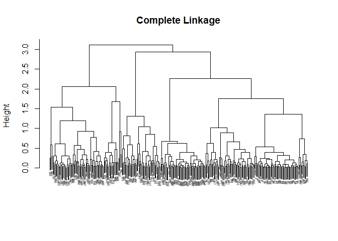

```r
hc.complete <- hclust(dist(dat.x), method = "complete")
plot(hc.complete, main = "Complete Linkage", xlab = "", sub = "", cex = .3)
```

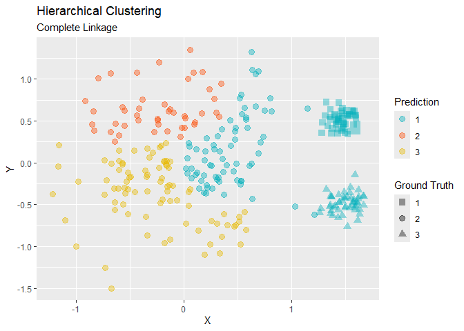

```r
plot_clust(dat, cutree(hc.complete, 3), "Hierarchical", "Complete Linkage")
```

### Single Linkage

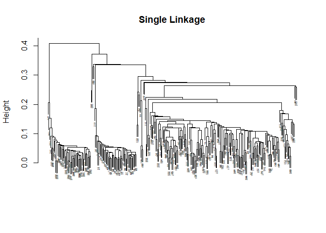

```r
hc.single <- hclust(dist(dat.x), method = "single")
plot(hc.single, main = "Single Linkage", xlab = "", sub = "", cex = .3)
```

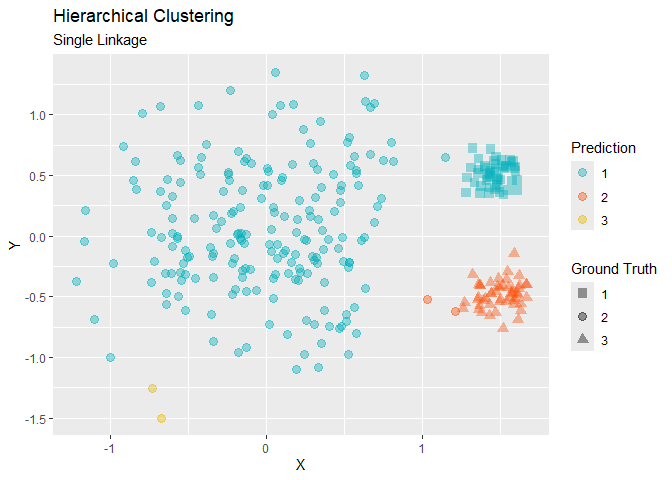

```r
plot_clust(dat, cutree(hc.single, 3), "Hierarchical", "Single Linkage")
```

### Average Linkage

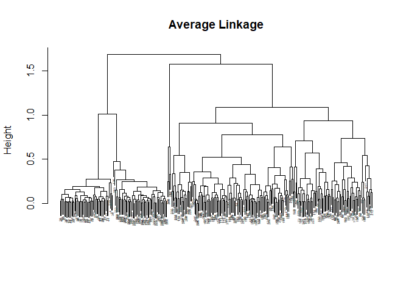

```r
hc.average <- hclust(dist(dat.x), method = "average")
plot(hc.average, main = "Average Linkage", xlab = "", sub = "", cex = .3)
```

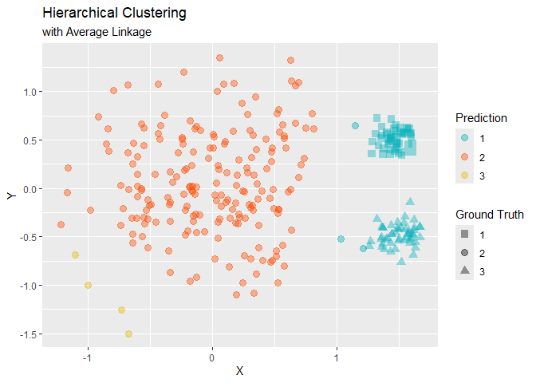

```r
plot_clust(dat, cutree(hc.average, 3), "Hierarchical", "with Average Linkage")
```

## Single vs. Complete Linkage

Hierarchical Methods:

- Single Linkage
  - calculates the minimum distance between clusters
  - distance between the closest points of two clusters.
  - tends to produce long, “loose” clusters.
  - sensitive to outliers
  - a.k.a the Nearest Point Algorithm
- Complete Linkage
  - calculates the maximum distance between clusters
  - distance between the farthest points of two clusters
  - tends to produce more compact clusters.
  - a.k.a. the Farthest Point Algorithm
- Average Linkage
  - calculates the average distance between clusters
  - average distance between all pairs of points in two different clusters

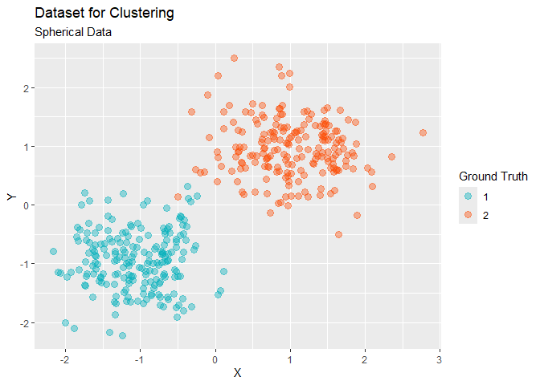

```r
set.seed(10)
df_round <- rbind(
  rbivariate(
    mean.x = -1, sd.x = 0.5, mean.y = -1, sd.y = 0.5, n = 200,
    label = 1
  ),
  rbivariate(
    mean.x = 1, sd.x = 0.5, mean.y = 1, sd.y = 0.5, n = 200,
    label = 2
  )
) %>% as.data.frame()
df_diag <- rbind(
  rbivariate(
    mean.x = 0, sd.x = .5, mean.y = 0, r = 0.8, sd.y = .5, n = 200,
    label = 1
  ),
  rbivariate(
    mean.x = 1.5, sd.x = .1, mean.y = -.5, sd.y = .1, n = 200,
    label = 2
  )
) %>% as.data.frame()

plot_data(data = df_round, subtitle = "Spherical Data")
```

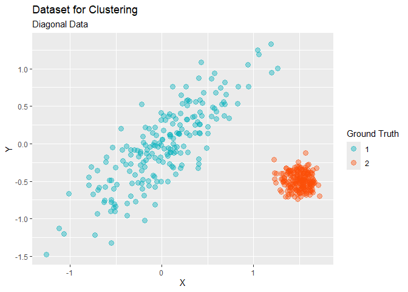

```r
plot_data(data = df_diag, subtitle = "Diagonal Data")
```

### Experiments

Spherical data + Single Linkage

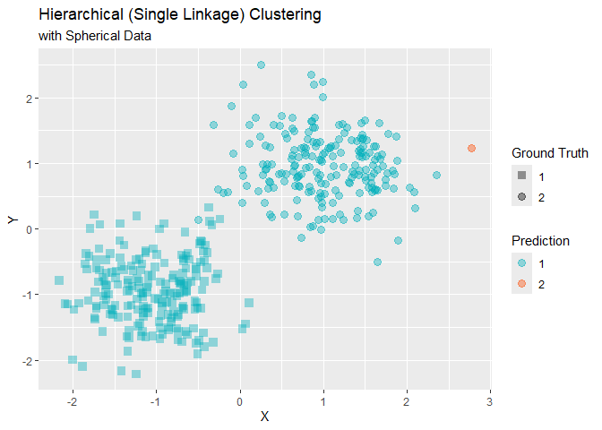

```r
df_round[, 1:2] %>%
  dist() %>%
  hclust(d = ., method = "single") %>%
  cutree(tree = ., k = 2) %>%
  plot_clust(
    data = df_round, label = ., "Hierarchical (Single Linkage)",
    "with Spherical Data"
  )
```

Spherical data + Complete Linkage

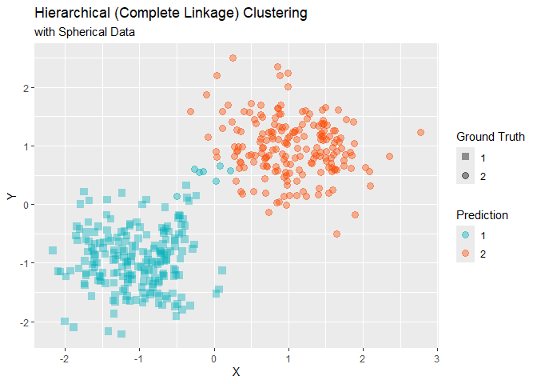

```r
df_round[, 1:2] %>%
  dist() %>%
  hclust(d = ., method = "complete") %>%
  cutree(tree = ., k = 2) %>%
  plot_clust(
    data = df_round, label = ., "Hierarchical (Complete Linkage)",
    "with Spherical Data"
  )
```

Diagonal data + Single Linkage

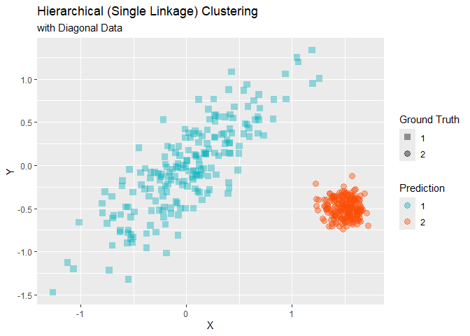

```r
df_diag[, 1:2] %>%
  dist() %>%
  hclust(d = ., method = "single") %>%
  cutree(tree = ., k = 2) %>%
  plot_clust(
    data = df_diag, label = ., "Hierarchical (Single Linkage)",
    "with Diagonal Data"
  )
```

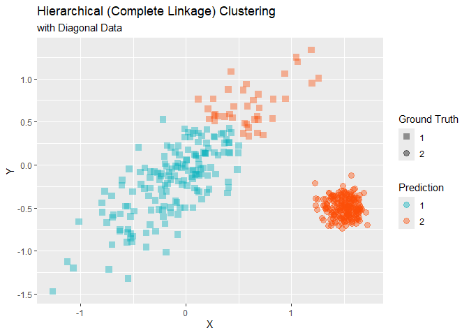

```r
df_diag[, 1:2] %>%
  dist() %>%
  hclust(d = ., method = "complete") %>%
  cutree(tree = ., k = 2) %>%
  plot_clust(
    data = df_diag, label = ., "Hierarchical (Complete Linkage)",
    "with Diagonal Data"
  )
```

## Gaussian Mixture Model (GMM)

```r
mdl <- mclust::Mclust(dat.x)
mdl %>% summary()
```

```
## ----------------------------------------------------
## Gaussian finite mixture model fitted by EM algorithm
## ----------------------------------------------------
##
## Mclust VII (spherical, varying volume) model with 3 components:
##
##  log-likelihood   n df       BIC       ICL
##       -382.6698 300 11 -828.0811 -830.7808
##
## Clustering table:
##   1   2   3
##  50 199  51
```

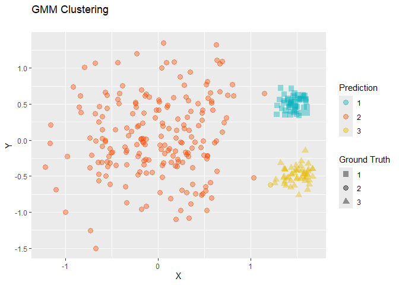

```r
plot_clust(data = dat, mdl$classification, "GMM")
```

## Appendix

### Distance

Formula of Minkowski Distance:

$$\left(\sum_{i=i}^d \left| x_i - y_i
\right|^p \right) ^\frac{1}{p}$$

We first specify a distance matrix:

```r
EG <- matrix(c(1, 2, 6, 2, 3, 1, 1, 3, 4, 5, 2, 4, 6, 0, 1),
  nrow = 5, ncol = 3
)
EG
```

```
##      [,1] [,2] [,3]
## [1,]    1    1    2
## [2,]    2    1    4
## [3,]    6    3    6
## [4,]    2    4    0
## [5,]    3    5    1
```

Calculate distances:

```r
# Minkowski Distance (p = 2)
dist(EG, "minkowski", diag = F, upper = F, p = 2)
```

```
##          1        2        3        4
## 2 2.236068
## 3 6.708204 4.898979
## 4 3.741657 5.000000 7.280110
## 5 4.582576 5.099020 6.164414 1.732051
```

```r
# Euclidean Distance
dist(EG, "euclidean", diag = F, upper = F)
```

```
##          1        2        3        4
## 2 2.236068
## 3 6.708204 4.898979
## 4 3.741657 5.000000 7.280110
## 5 4.582576 5.099020 6.164414 1.732051
```

### Explained Variance Ratio

- No universal threshold
- Always increase when $K$ increases

Between class

$$\text{SS}_{bt} = \sum_{i=1}^{k} n_i
\cdot (\bar{x}_i - \bar{x})^2$$

Total

$$\text{SS}_{tot} = \sum_{i=i}^{k}
\sum_{j=1}^{n_i} (x_{ij} - \bar{x})^2$$

Within-Cluster

$$\text{SS}_{in} = \sum_{i=1}^{k}
\sum_{j=1}^{n_i} (x_{ij} - \bar{x}_{i})^2$$